# HW2

Author

Emilia Ilioski

This is the link to the repo: https://github.com/emiilioski/Stats-506-Coursework.git

Question 1:

```r
#part a
#install.packages("roxygen2")
#' momentum_walk: calculate the particle's ending coordinates using n steps and probability p
#'
#' @returns a pair of coordinates
#' @export
#' @param n is greater than or equal to 1
#' @param p is between 0 and 1
#' @examples momentum_walk(3,.5)
momentum_walk <- function(n,p) {
  # sanitize 'input':
  if (!is.numeric(n) || length(n) != 1 || n < 1) {
    stop("n must be one number >= 1")
  }
  if (!is.numeric(p) || length(p) != 1 || p < 0 || p > 1) {
    stop("p must be one number between 0 and 1")
  }
  directions <- c("r", "l", "u","d")
  prev <- sample(directions, size = 1, replace = TRUE)
  coordinates <- c(0,0)
  i <-  0
  while (i < n) {
    options <- c("prev", "diff")
    chosen <- sample(options, prob = c(p, 1-p), size = 1, replace = TRUE)
    if (chosen != "prev") {
      prev <- sample(directions, size = 1, replace = TRUE)
    }
    if (prev == "r"){
        coordinates[1] = coordinates[1] + 1
    }
    else if (prev == "l") {
        coordinates[1] = coordinates[1] - 1
    }
    else if (prev == "u") {
        coordinates[2] = coordinates[2] + 1
    }
    else {
        coordinates[2] = coordinates[2] - 1
    }
    i = i + 1
  }
  return (coordinates)
}
```

```r
# part b
#version one with for loop
#' momentum_walk1: calculate the particle's ending coordinates using n steps and probability p, utilizing a for loop
#'
#' @returns a pair of coordinates
#' @export
#' @param n is greater than or equal to 1
#' @param p is between 0 and 1
#' @examples momentum_walk1(10, 0.6), momentum_walk1(1000, 0.6)
momentum_walk1 <- function(n,p) {
  # sanitize 'input':
  if (!is.numeric(n) || length(n) != 1 || n < 1) {
    stop("n must be one number >= 1")
  }
  if (!is.numeric(p) || length(p) != 1 || p < 0 || p > 1) {
    stop("p must be one number between 0 and 1")
  }
  directions <- c("r", "l", "u","d")
  prev <- sample(directions, size = 1, replace = TRUE)
  coordinates <- c(0,0)
  i <-  0
  for (i in seq_len(n)) {
    options <- c("prev", "diff")
    chosen <- sample(options, prob = c(p, 1-p), size = 1, replace = TRUE)
    if (chosen != "prev") {
      prev <- sample(directions, size = 1, replace = TRUE)
    }
    if (prev == "r"){
        coordinates[1] = coordinates[1] + 1
    }
    else if (prev == "l") {
        coordinates[1] = coordinates[1] - 1
    }
    else if (prev == "u") {
        coordinates[2] = coordinates[2] + 1
    }
    else {
        coordinates[2] = coordinates[2] - 1
    }
  }
  return (coordinates)
}

#version 2
#' momentum_walk2: calculate the particle's ending coordinates using n steps and probability p, utilizing sapply
#'
#' @returns a pair of coordinates
#' @export
#' @param n is greater than or equal to 1
#' @param p is between 0 and 1
#' @examples momentum_walk2(10, 0.6), momentum_walk2(1000, 0.6)
momentum_walk2 <- function(n,p) {
   # sanitize 'input':
  if (!is.numeric(n) || length(n) != 1 || n < 1) {
    stop("n must be one number >= 1")
  }
  if (!is.numeric(p) || length(p) != 1 || p < 0 || p > 1) {
    stop("p must be one number between 0 and 1")
  }
  directions <- c("r", "l", "u","d")
  prev <- sample(directions, size = 1, replace = TRUE)
  steps <- sapply(1:n, function(i) {
    chosen <- sample(c("prev","diff"), 1, prob = c(p,1-p))
    if (chosen != "prev") {
      prev <<- sample(directions, 1, replace = TRUE)
    }
    prev
  })
  x <- sum(steps == "r") - sum(steps == "l")
  y <- sum(steps == "u") - sum(steps == "d")
  return (c(x,y))
}
momentum_walk1(10, 0.6)
```

```
[1] -8 -2
```

```r
momentum_walk2(10, 0.6)
```

```
[1] -8  0
```

```r
momentum_walk1(1000, 0.6)
```

```
[1]  -9 -53
```

```r
momentum_walk2(1000, 0.6)
```

```
[1] 23 33
```

The logic behind the first version is that it loops n times. Each time it samples a either previous or other direction with previous direction probability p, then it checks if it matches the previous direction, if not it updates the previous direction using a sample of the directions. Then it moves the appropriate coordinate based on the direction sampled.

The logic behind the second version is that it uses sapply to apply a function which samples a previous direction or other direction n times with previous direction probability p and then checks if it matches the previous direction, if not it updates the previous direction and samples for the other direction. Then it sums up how many times each direction occurred and then updates the coordinates accordingly.

```r
# part c
set.seed(25)
momentum_walk1(10, 0.6)
```

```
[1]  2 -6
```

```r
set.seed(25)
momentum_walk1(10, 0.6)
```

```
[1]  2 -6
```

```r
set.seed(25)
momentum_walk1(1000, 0.6)
```

```
[1] -29  13
```

```r
set.seed(25)
momentum_walk1(1000, 0.6)
```

```
[1] -29  13
```

The random numbers from R come from a random number generator which uses an algorithm. Set seed resets the alogrithm to the same starting point/state and thus sample() will output the same thing each time because of the set.seed. Though it is important to set the seed before each call to the function, because each time the function uses random numbers

```r
#part d
set.seed(25)
vec1 <- momentum_walk1(1000, 0)
vec2 <- momentum_walk1(1000, 0.5)
vec3 <- momentum_walk1(1000, 0.9)
sqrt(vec1[1]**2 + vec1[2]**2)
```

```
[1] 43.909
```

```r
sqrt(vec2[1]**2 + vec2[2]**2)
```

```
[1] 54.57105
```

```r
sqrt(vec3[1]**2 + vec3[2]**2)
```

```
[1] 107.2007
```

The momentum appears to increase the final distance because the .9 probability has the highest distance. It is about double the other two distances. This makes sense because with p =0 the steps are pretty random so they end up canceling each other out often but with p = .9 the particle goes the same direction for a while so less cancellation thus higher distance.

```r
#part e
set.seed(250)
probs <- c(0,.25, .5, .75, .9)
dists <- c()
meanDists <- c()
for (i in 1:length(probs)) {
    distances <- replicate(1000, {
        location <- momentum_walk1(1000, probs[i])
        sqrt(location[1]^2 + location[2]^2)})
    meanDists[i] = mean(distances)
}
results <- data.frame(p = probs, mean_distance = meanDists)
print(results)
```

```
     p mean_distance
1 0.00      28.12447
2 0.25      36.47399
3 0.50      48.84285
4 0.75      74.56973
5 0.90     123.18346
```

The average distance increases as the probability p increases. The average distance grows faster at a larger p. Notably, p = 0 distance is approximately 4-5 times smaller than p =.9’s distance

```r
# part f
library(microbenchmark)
microbenchmark(
  mw1  = momentum_walk1(1000, 0.6),
  mw2 = momentum_walk2(1000, 0.6),
  times = 50)
```

```
Unit: milliseconds
 expr      min       lq     mean   median       uq      max neval cld
  mw1 3.866792 4.038049 4.496568 4.235567 4.365762 6.573940    50   a
  mw2 4.081509 4.234234 4.835025 4.383453 4.720576 8.866414    50   a
```

```r
microbenchmark(
  mw11  = momentum_walk1(100000, 0.6),
  mw22 = momentum_walk2(100000, 0.6),
  times = 5)
```

```
Unit: milliseconds
 expr      min       lq     mean   median       uq      max neval cld
 mw11 451.7149 451.9113 466.0624 451.9810 468.4489 506.2558     5   a
 mw22 469.4841 485.3714 533.0718 504.7628 515.1644 690.5764     5   a
```

Problem 2:

```r
set.seed(250)
day <- function() {
  sum(rpois(3,4)) +
  rnorm(1, 45, sqrt(16)) +
  sum(rpois(6,15)) +
  rnorm(1, 55, sqrt(25)) +
  sum(rpois(6,9))
}
mean(replicate(10000, day()))
```

```
[1] 255.5604
```

Expected number of total passengers who board the bus per day is 255.56 or about 256

Problem 3:

```r
youtube <- read.csv(
  "https://raw.githubusercontent.com/rfordatascience/tidytuesday/master/data/2021/2021-03-02/youtube.csv"
)
```

```r
#part a
library(tidyverse)
head(youtube)
```

```
  year     brand
1 2018    Toyota
2 2020 Bud Light
3 2006 Bud Light
4 2018   Hynudai
5 2003 Bud Light
6 2020    Toyota
                                             superbowl_ads_dot_com_url
1                          https://superbowl-ads.com/good-odds-toyota/
2 https://superbowl-ads.com/2020-bud-light-seltzer-inside-posts-brain/
3                https://superbowl-ads.com/2006-bud-light-bear-attack/
4  https://superbowl-ads.com/hope-detector-nfl-super-bowl-lii-hyundai/
5                https://superbowl-ads.com/2003-bud-light-hermit-crab/
6 https://superbowl-ads.com/2020-toyota-go-places-with-cobie-smulders/
                                  youtube_url funny show_product_quickly
```

[output cut: 55 more lines]

```r
youtubeClean <- youtube |> select(-title, -etag, -youtube_url, -superbowl_ads_dot_com_url, -brand, -thumbnail, -description, -channel_title, -published_at, -id, -kind)
head(youtubeClean)
```

```
  year funny show_product_quickly patriotic celebrity danger animals use_sex
1 2018 FALSE                FALSE     FALSE     FALSE  FALSE   FALSE   FALSE
2 2020  TRUE                 TRUE     FALSE      TRUE   TRUE   FALSE   FALSE
3 2006  TRUE                FALSE     FALSE     FALSE   TRUE    TRUE   FALSE
4 2018 FALSE                 TRUE     FALSE     FALSE  FALSE   FALSE   FALSE
5 2003  TRUE                 TRUE     FALSE     FALSE   TRUE    TRUE    TRUE
6 2020  TRUE                 TRUE     FALSE      TRUE   TRUE    TRUE   FALSE
  view_count like_count dislike_count favorite_count comment_count category_id
1     173929       1233            38              0            NA           1
2      47752        485            14              0            14          27
3     142310        129            15              0             9          17
4        198          2             0              0             0          22
5      13741         20             3              0             2          24
6      23636        115            11              0            13           1
```

```r
print(dim(youtubeClean))
```

```
[1] 247  14
```

There are now 14 columns and 247 rows.

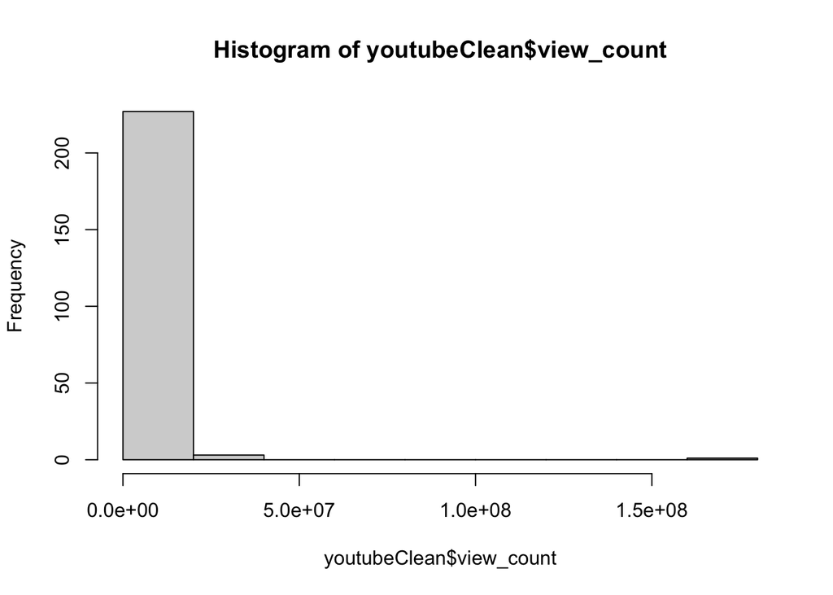

```r
# part b
hist(youtubeClean$view_count)
```

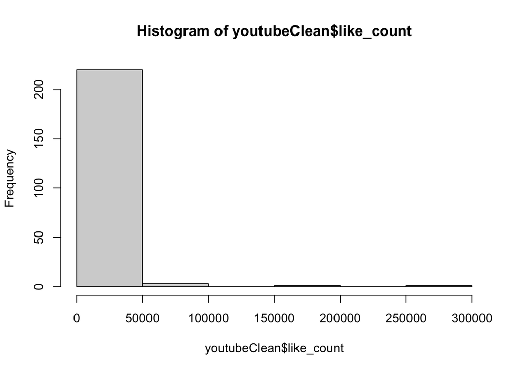

```r
hist(youtubeClean$like_count)
```

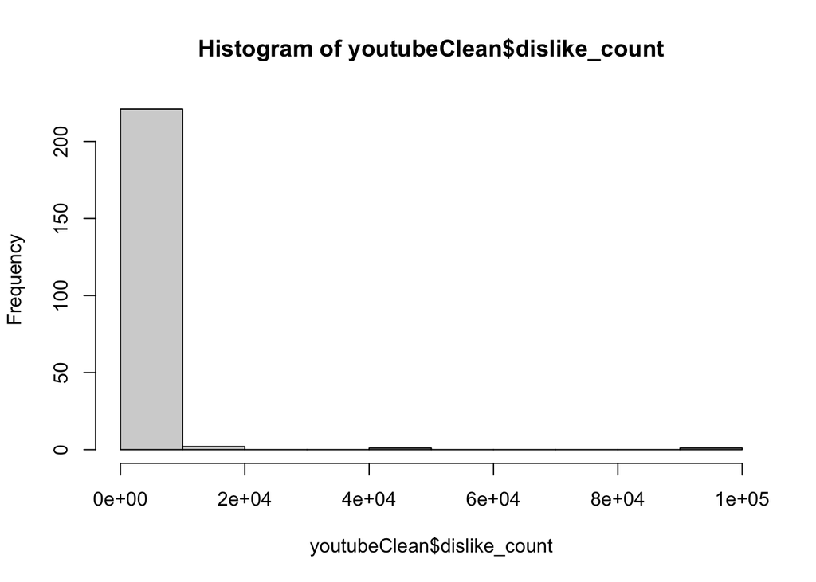

```r
hist(youtubeClean$dislike_count)
```

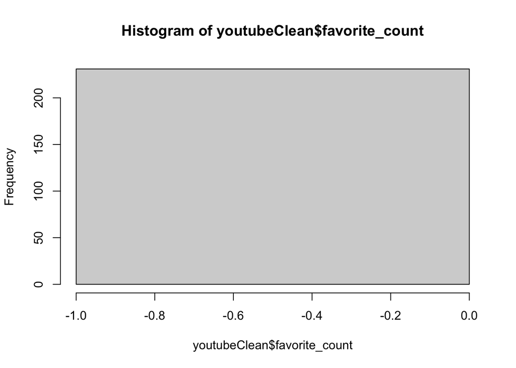

```r
hist(youtubeClean$favorite_count)
```

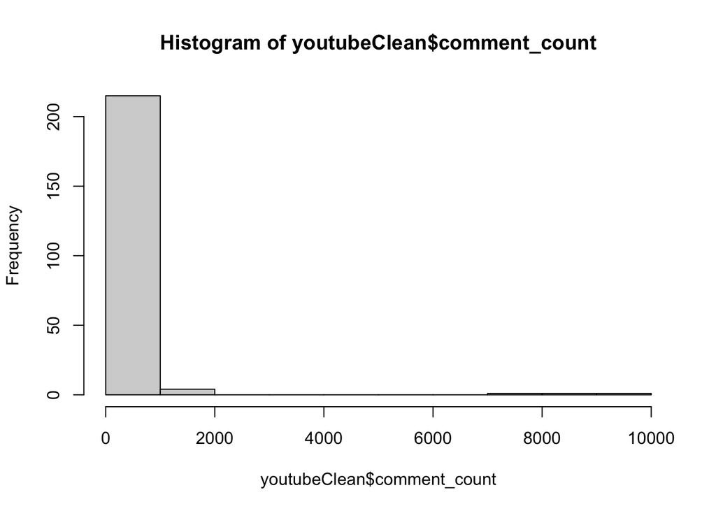

```r
hist(youtubeClean$comment_count)
```

For view_count, like_count, dislike_count, and comment_count all of these are heavily right-skewed which goes against the rule that we want normal residuals and constant variance for linear regressions. So these would all should be transformed. Thus, I will be using a log transformation. The log transformation would scale the counts better so that it is not as skewed.

For favorite_count, this would not be appropriate to use for the model because there’s basically no variation. In the histogram it appears as one block because most of the favorite_count is zero. Thus this would not be helpful in a model.

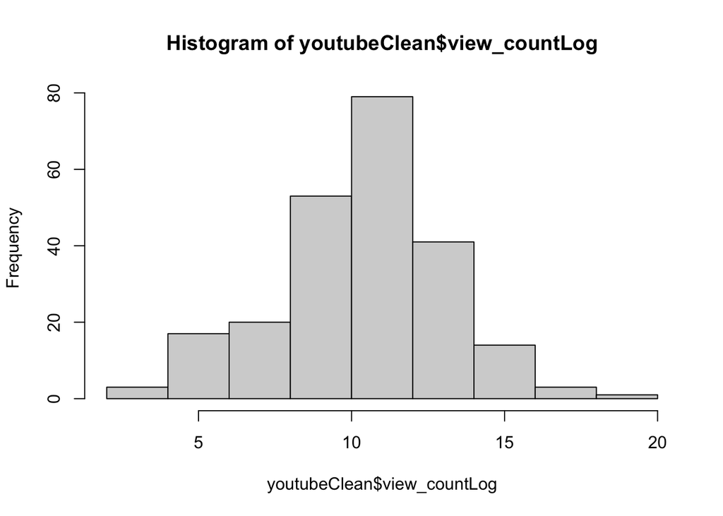

```r
# part b transformations
youtubeClean$view_countLog <- log1p(youtubeClean$view_count)
youtubeClean$like_countLog <- log1p(youtubeClean$like_count)
youtubeClean$dislike_countLog <- log1p(youtubeClean$dislike_count)
youtubeClean$comment_countLog <- log1p(youtubeClean$comment_count)
hist(youtubeClean$view_countLog)
```

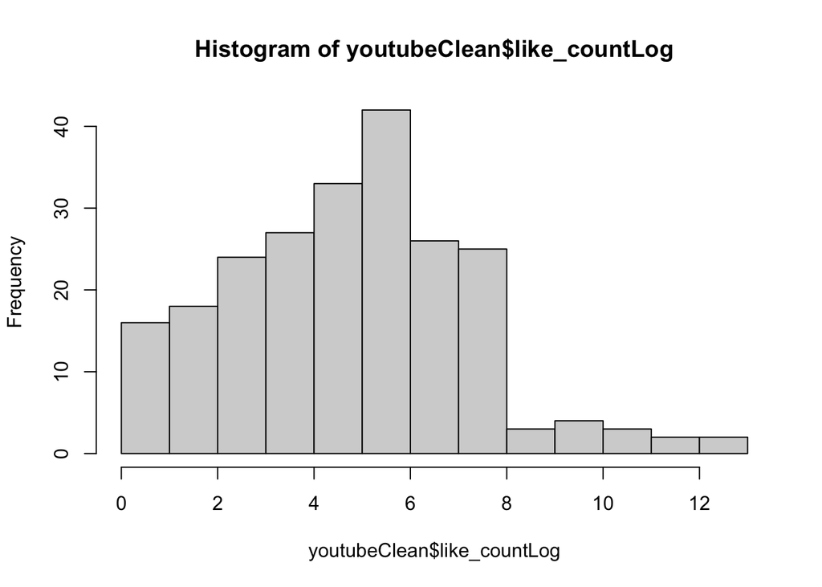

```r
hist(youtubeClean$like_countLog)
```

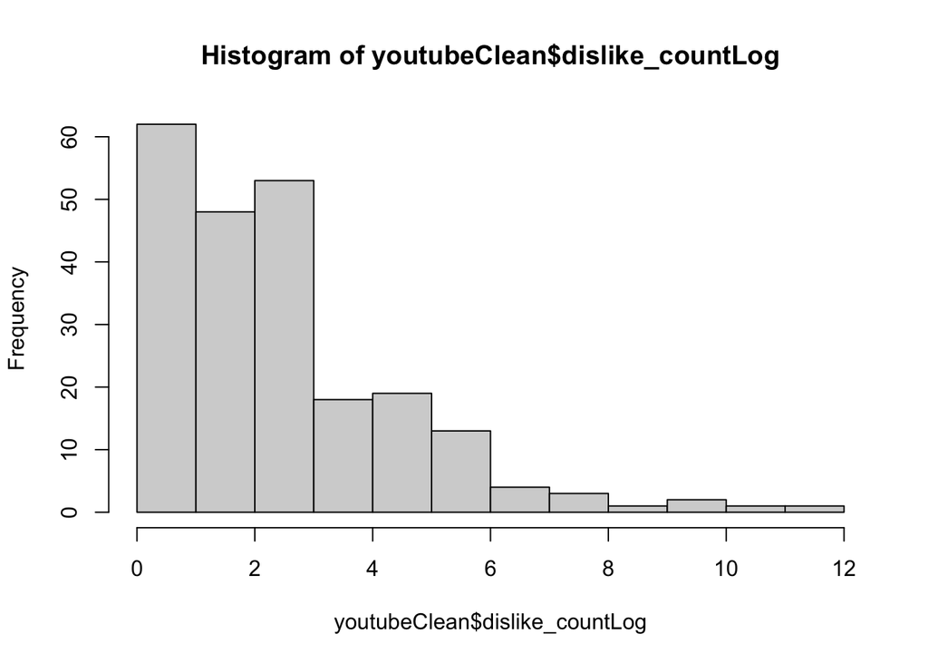

```r
hist(youtubeClean$dislike_countLog)
```

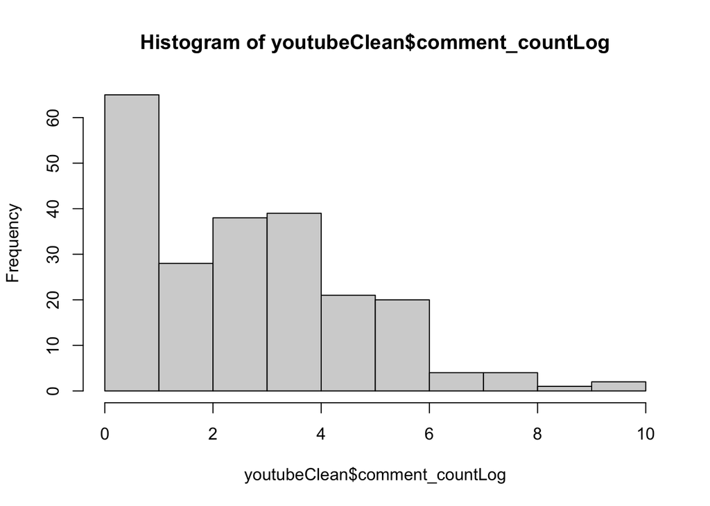

```r
hist(youtubeClean$comment_countLog)
```

They are still a little skewed but much less than before, and the spread looks much better (more visible variation).

```r
#part c
#set.seed(25)
outcomes <- c("view_countLog", "like_countLog", "dislike_countLog", "comment_countLog")
#sapply(youtubeClean, class)
binaryCharacteristics <- c("patriotic", "animals", "funny", "celebrity", "use_sex", "show_product_quickly", "danger")
results <- data.frame()
for (i in outcomes) {
  for (j in binaryCharacteristics) {
    fit <- lm(as.formula(paste(i, "~", j, "+ year")), data = youtubeClean)
    coefs <- summary(fit)$coefficients[2, ]
    results <- rbind(results, data.frame(outcome = i, characteristic = j, estimate = coefs["Estimate"], p_value = coefs["Pr(>|t|)"]))
  }
}
rownames(results) <- NULL
results$significant <- results$p_value < .05
print(results)
```

```
            outcome       characteristic    estimate    p_value significant
1     view_countLog            patriotic  0.13692497 0.78391866       FALSE
2     view_countLog              animals -0.17326980 0.64669142       FALSE
3     view_countLog                funny  0.52984356 0.20510610       FALSE
4     view_countLog            celebrity -0.01898556 0.96288885       FALSE
5     view_countLog              use_sex -0.29629543 0.49051595       FALSE
6     view_countLog show_product_quickly  0.20898031 0.60072225       FALSE
7     view_countLog               danger  0.66678076 0.09406479       FALSE
8     like_countLog            patriotic  0.49311233 0.28968290       FALSE
9     like_countLog              animals  0.02459257 0.94282914       FALSE
10    like_countLog                funny  0.36019066 0.34005646       FALSE
11    like_countLog            celebrity  0.26297830 0.47787826       FALSE
12    like_countLog              use_sex -0.32497453 0.40008928       FALSE
13    like_countLog show_product_quickly  0.16825538 0.64047730       FALSE
14    like_countLog               danger  0.62526219 0.08031647       FALSE
15 dislike_countLog            patriotic  0.66965405 0.08563747       FALSE
16 dislike_countLog              animals -0.07378053 0.79742453       FALSE
17 dislike_countLog                funny  0.04148774 0.89580597       FALSE
18 dislike_countLog            celebrity -0.28325315 0.36162721       FALSE
19 dislike_countLog              use_sex -0.38888066 0.22927926       FALSE
20 dislike_countLog show_product_quickly  0.24290875 0.42097425       FALSE
21 dislike_countLog               danger  0.18514931 0.53794989       FALSE
22 comment_countLog            patriotic  0.51478460 0.16854269       FALSE
23 comment_countLog              animals -0.19176266 0.49906680       FALSE
24 comment_countLog                funny  0.04746590 0.87934573       FALSE
25 comment_countLog            celebrity  0.22806291 0.45558834       FALSE
26 comment_countLog              use_sex -0.34939714 0.27353634       FALSE
27 comment_countLog show_product_quickly  0.34602814 0.24685774       FALSE
28 comment_countLog               danger  0.10642262 0.72095533       FALSE
```

None of them have statistically significant evidence of an association as all the p-values are greater than 0.05 thus there is not enough evidence to support associations.

Additionally, the commercial characteristic that has the largest positive estimated association with view counts is danger with the estimate at .66678.

```r
#part d
#from part c the binary commerical characteristic with the smallest p-value for predicting view counts is danger
set.seed(100)
youtube2 <- youtubeClean[complete.cases(youtubeClean[, c("view_countLog", "danger", "year")]), ]
X <- cbind(1, as.numeric(youtube2$danger), youtube2$year)
colnames(X) <- c("intercept", "danger", "year")
y <- youtube2$view_countLog
Bhat <- solve(t(X) %*% X) %*% t(X) %*% y
fit <- lm(view_countLog ~ danger + year, data = youtube2)
coef(fit)
```

```
 (Intercept)   dangerTRUE         year
-31.39149243   0.66678076   0.02065641
```

```r
all.equal(as.numeric(Bhat), as.numeric(coef(fit)))
```

```
[1] TRUE
```

They both the get the same coefficient estimates, which shows that the matrix calculation works the same as lm().